# Homework 6

Katarzyna Kanska

12.11.2015

## Goals

Now consider scenario with ,,unequal slopes’’ - an interaction between continuous and categorical variable. We are going to check when such interaction can be detected.

Create following scenarios:

Generate continuous variable `X_1` from distribution `U[0,1]`. Generate categorical variable `X_2` with 2 levels with equal frequency). Generate Y in a way that it depends on interaction of `X_1` and `X_2`.

1. Add random noise from N(0,1), all ANCOVA assumptions are met.
2. Choose other distribution for epsilons, find a distribution with the same scale as N(0,1) for which you will get drop in power.
3. Choose other distribution for epsilons in a way that the test for residual will not keep I type error rate.

For all these scenarios, produce plot that will compare power as a function of sample size. Moreover on this plot is should be visible that power for scenario 2 is lower than for scenario 1. And that I type error rate is different for scenario 3 and scenario 1.

## Solution

### Preparing dataset

We have three variables:

- `X_1` from distribution `U[0,1]`,
- `X_2` categorical variable with 2 levels (`A`, `B`) with equal frequency,
- `Y` depends on interaction of `X_1` and `X_2`.

This dependence will be linear, different in each of `X_2` levels.

```r
myDistribution <- function(N, distribution, m, sigma2) {
  return(switch(distribution,
                normal=rnorm(2*N, m, sqrt(sigma2)),
                uniform=runif(2*N, min = m - sqrt(12*sigma2)/2, max = m + sqrt(12*sigma2)/2),
                pseudoexponential = m + rexp(N, 1/sqrt(sigma2))*sample(c(-1,1), size=2*N, replace=TRUE)
                )
         )
}

GenData <- function(M, distribution, m, sigma2){
  '
    M is 1/2 of sample size

    possible distributions of random noise:
      normal,
      uniform,
      pseudoexponential: F = m + H * J,
                        where H is from exponential distribution with variance equal sigma2,
                        J is 1 or -1 (with probability 1/2)

    characteristics of chosen distribution:
    m - mean
    sigma2 - variance

  '

  X_1 <- runif(2*M, min = 0, max = 1)
  X_2 <- rep(c("A","B"), times=M)

  Y <- myDistribution(2*M, distribution, m, sigma2)

  # generate interactions
  Y[X_2=="A"] <- Y[X_2=="A"] + 0.5*X_1[X_2=="A"]
  Y[X_2=="B"] <- Y[X_2=="B"] + 2*X_1[X_2=="B"]

  df <- data.frame(Y, X_1, X_2 = factor(X_2))

  return(df)
}
```

### Adding random noise from N(0,1), all ANCOVA assumptions are met.

Let us see the result for sample size `N` = 500.

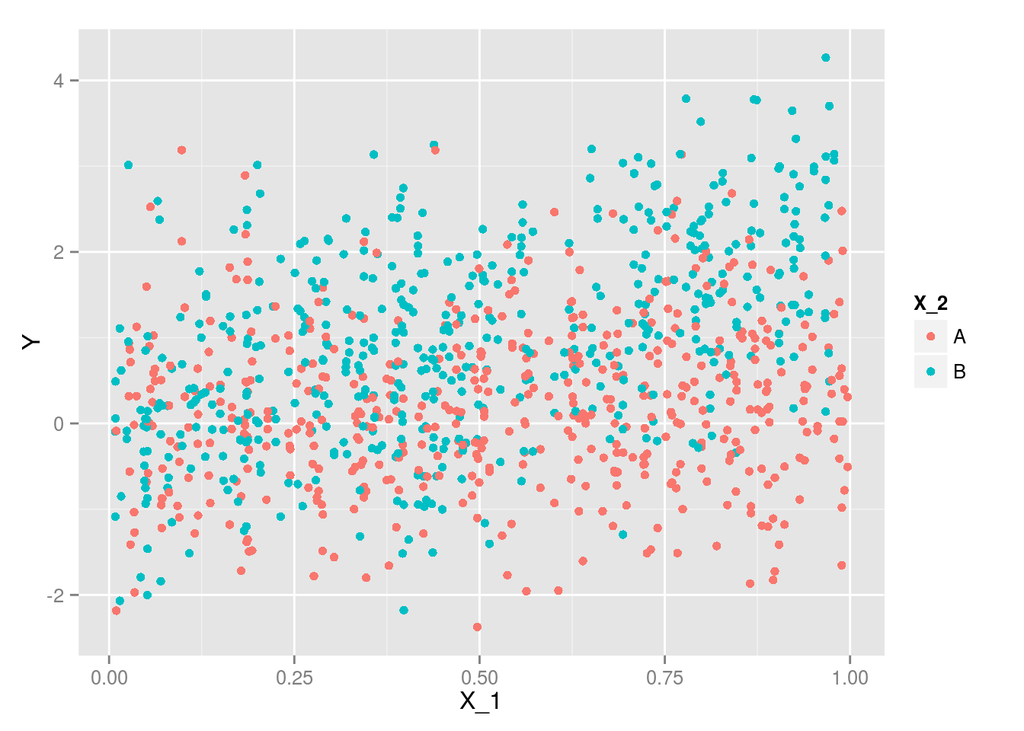

```r
set.seed(7)

M <- 250

# generate data
df <- GenData(M, "normal", 0, 1)

library("ggplot2")
ggplot(df, aes(x=X_1, y=Y, color=X_2)) + geom_point()
```

We can see that `Y` reacts differently to `X_1` depending on `X_2` value.

### Choice of distribution for epsilons, find a distribution with the same scale as N(0,1) for which you will get drop in power.

Firstly, let us try the uniform distribution for random noise.

```r
CalcPower <- function(N, M, distribution, m, sigma2){
  '
  Function calculate the power of F test used in diagnostics of a linear model with two categorical variables (one nested effect).
  The significance level is set to 0.05.

  Input:
    N - numeric (number of simulations)
    M - numeric (1/2 of sample size)
    distribution - string (name of distribution for random noise)
    m, sigma2 - numeric (mean and variance of above distribution)
  Output:
    power - numeric (power of the F test for nested effect)
  '

  alpha <- 0.05

  pvals <- replicate(N,
                     {
                       df <- GenData(M, distribution, m, sigma2)
                       model <- lm(Y ~ X_1*X_2, data=df)
                       interactions <- summary(aov(model))[[1]][3,5]
                       normality <- shapiro.test(rstandard(model))[2]
                       c(interactions, normality)
                     })

  power.int <- round(100*mean(pvals[1,] < alpha),1)
  power.resid <- round(100*mean(pvals[2,] < alpha),1)

  return(c(power.int, power.resid))
}
```

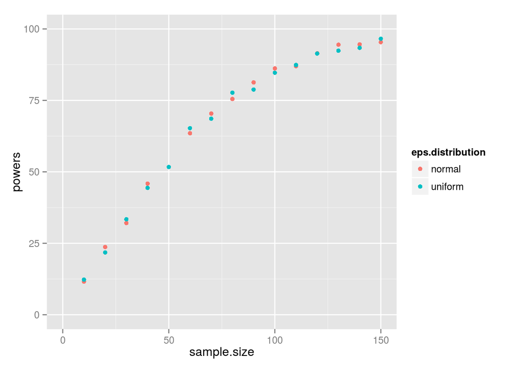

```r
set.seed(7)

# 1/2 of sample size
M <- 75
# number of simulations used to calculate power of F test
N <- 1000

sample.size <- seq(5, M, by = 5)

powers.norm <- sapply(sample.size, function(x) CalcPower(N, x, "normal", 0, 1))
powers.unif <- sapply(sample.size, function(x) CalcPower(N, x, "uniform", 0, 1))

powers.df <- data.frame(sample.size = 2*rep(sample.size, times=2),
                        powers = c(powers.norm[1,], powers.unif[1,]),
                        eps.distribution = factor(c(rep("normal", times=length(sample.size)),
                                             rep("uniform", times=length(sample.size)))))

ggplot(powers.df, aes(x=sample.size, y=powers, color=eps.distribution)) +
  geom_point() +
  xlim(0, 2*M) +
  ylim(0, 100)
```

We cannot see much difference in test power.

Now let us try the pseudo-exponential distribution.

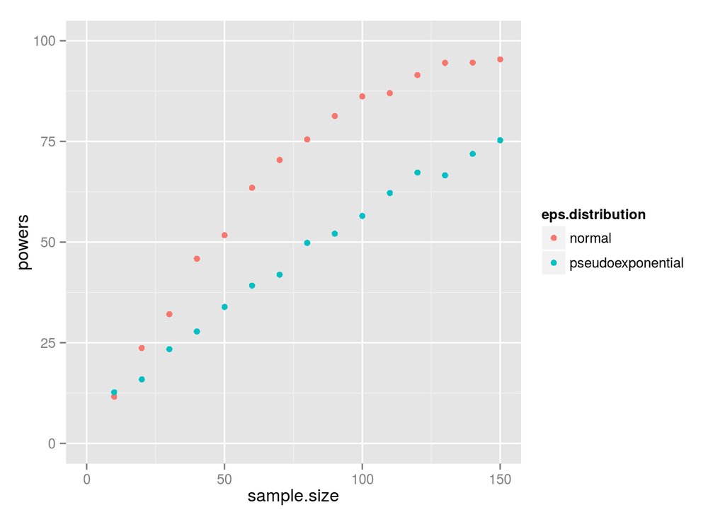

```r
set.seed(7)

powers.pseudoexp <- sapply(sample.size, function(x) CalcPower(N, x, "pseudoexponential", 0, 1))

powers.df <- data.frame(sample.size = 2*rep(sample.size, times=2),
                        powers = c(powers.norm[1,], powers.pseudoexp[1,]),
                        eps.distribution = factor(c(rep("normal", times=length(sample.size)),
                                                    rep("pseudoexponential", times=length(sample.size)))))

ggplot(powers.df, aes(x=sample.size, y=powers, color=eps.distribution)) +
  geom_point() +
  xlim(0, 2*M) +
  ylim(0, 100)
```

Here can observe significant difference in test power. The question which arises now is why uniform distribution of random noise failed to decrese the test power, while this strange pseudo-exponential distribution achieved that?

Let us compare the histograms.

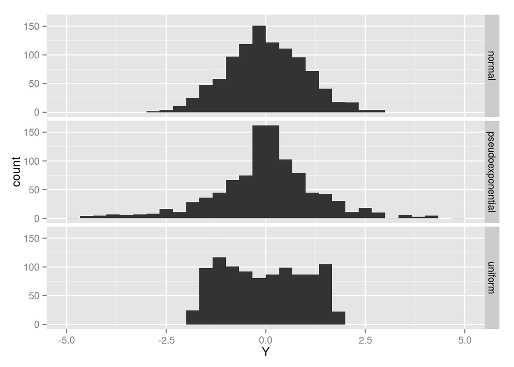

```r
set.seed(7)
M <- 500

df.norm <- myDistribution(M, "normal", 0, 1)
df.unif <- myDistribution(M, "uniform", 0, 1)
df.pseudoexp <- myDistribution(M, "pseudoexponential", 0, 1)

df <- data.frame(Y = c(df.norm, df.unif, df.pseudoexp),
                 distribution = factor(c(rep("normal", times=2*M),
                                         rep("uniform", times=2*M),
                                         rep("pseudoexponential", times=2*M))))

ggplot(df, aes(x=Y)) + geom_histogram() +
  xlim(-5, 5) + facet_grid(distribution ~ .)
```

Probably long tails of exponential distribution were crucial.

### Choice of distribution for epsilons in a way that the test for residual will not keep I type error rate.

Firstly, we recall the definition of type I error - it is the incorrect rejection of a true null hypothesis (a “false positive”).

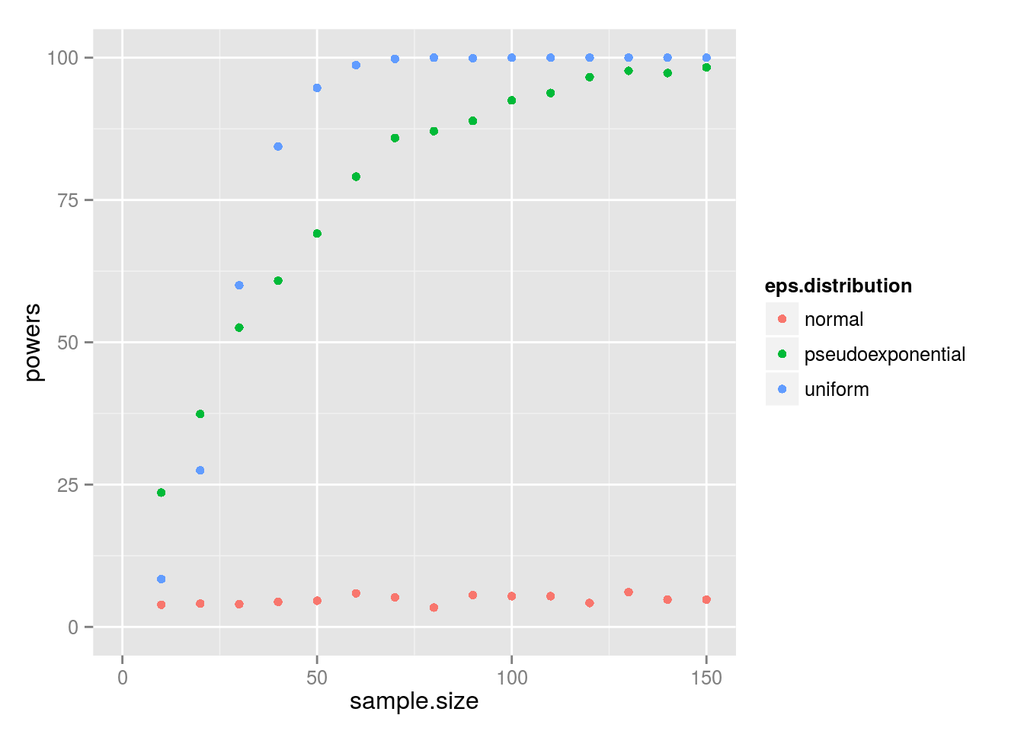

```r
powers.df2 <- data.frame(sample.size = 2*rep(sample.size, times=3),
                        powers = c(powers.norm[2,], powers.unif[2,], powers.pseudoexp[2,]),
                        eps.distribution = factor(c(rep("normal", times=length(sample.size)),
                                                    rep("uniform", times=length(sample.size)),
                                                    rep("pseudoexponential", times=length(sample.size)))))

ggplot(powers.df2, aes(x=sample.size, y=powers, color=eps.distribution)) +
  geom_point() +
  xlim(0, 2*max(sample.size)) +
  ylim(0, 100)
```

Here we see that both uniform and pseudo-exponential distribution of residuals are detected by Shapiro-Wilk test for normality.

### Conclusions

These conclusions are very optimistic. However, we tested only two kinds of non-normal distribution (one whose density has a compact support, another one with tails), which might be not enough to state with certainty that above conclusions are correct.